# Life Expectancy States

2024-06-06

### Carregando os pacotes

```r
library(convergEU)
library(knitr)
library(tibble)
library(tidyverse)
library(eurostat)
library(purrr)
library(tidyr)
library(ggplot2)
library(kableExtra)
options(kableExtra.auto_format = FALSE)
library(caTools)
library(broom)
library(gridExtra)
library(flextable)
library(flexmix)
library(formattable)
library(officer)
library(leaflet)
library(magrittr)
library(leaflet.extras)
library(png)
library(purrr)
library(htmltools)
library(htmlwidgets)
library(rmarkdown)
library(webshot)
library(webshot2)
```

### Carregando a base de dados

```r
life_exp_states = read.csv("life_exp_states_br.csv")
head(life_exp_states)
```

```
##   time   X11   X12   X13   X14   X15   X16   X17   X21   X22   X23   X24   X25
## 1 2012 70.50 72.47 70.85 70.10 71.23 72.77 72.11 69.34 70.19 72.78 74.59 71.80
## 2 2013 70.71 72.84 71.11 70.44 71.44 73.07 72.42 69.65 70.38 73.03 74.86 72.15
## 3 2014 70.91 73.21 71.36 70.77 71.64 73.37 72.71 69.96 70.57 73.26 75.13 72.48
## 4 2015 71.11 73.56 71.61 71.10 71.84 73.65 73.01 70.25 70.76 73.49 75.38 72.79
## 5 2016 71.30 73.89 71.85 71.41 72.03 73.92 73.29 70.54 70.94 73.72 75.62 73.09
## 6 2017 71.50 74.20 72.08 71.71 72.22 74.18 73.56 70.83 71.12 73.94 75.87 73.39
##     X26   X27   X28   X29   X31   X32   X33   X35   X41   X42   X43   X50   X51
## 1 72.03 69.96 71.47 72.39 76.12 76.78 74.90 76.80 75.76 77.70 76.62 74.35 73.16
## 2 72.50 70.37 71.76 72.66 76.40 77.17 75.23 77.15 76.09 78.07 76.91 74.65 73.43
## 3 72.94 70.77 72.03 72.91 76.69 77.54 75.56 77.47 76.40 78.42 77.21 74.94 73.69
## 4 73.37 71.16 72.30 73.16 76.96 77.89 75.88 77.78 76.72 78.76 77.49 75.22 73.95
## 5 73.78 71.54 72.55 73.40 77.23 78.22 76.18 78.07 77.02 79.09 77.77 75.49 74.20
## 6 74.16 71.90 72.80 73.64 77.49 78.53 76.47 78.35 77.32 79.40 78.04 75.74 74.44
##     X52   X53
## 1 73.41 76.87
## 2 73.58 77.17
## 3 73.75 77.47
## 4 73.92 77.75
## 5 74.09 78.02
## 6 74.26 78.27
```

### Beta-convergence

```r
c(min(life_exp_states$time), max(life_exp_states$time))
```

```
## [1] 2012 2021
```

```r
empBC = beta_conv(life_exp_states,
                  time_0 = 2012,
                  time_t = 2021,
                  all_within = FALSE,
                  timeName = 'time')
empBC
```

```
## $res
## $res$workTB
## # A tibble: 27 × 3
##    deltaIndic indic countries
##         <dbl> <dbl> <chr>
##  1  -0.00262   4.26 X11
##  2  -0.000322  4.28 X12
##  3  -0.00196   4.26 X13
##  4  -0.000620  4.25 X14
##  5  -0.00254   4.27 X15
##  6  -0.00165   4.29 X16
##  7  -0.000572  4.28 X17
##  8  -0.00233   4.24 X21
##  9  -0.00259   4.25 X22
## 10  -0.00117   4.29 X23
## # ℹ 17 more rows
##
## $res$model
##
## Call:
## stats::lm(formula = deltaIndic ~ indic, data = workTB)
##
## Coefficients:
## (Intercept)        indic
##     0.13421     -0.03189
##
##
## $res$summary
## # A tibble: 2 × 5
##   term        estimate std.error statistic p.value
##   <chr>          <dbl>     <dbl>     <dbl>   <dbl>
## 1 (Intercept)   0.134     0.0587      2.29  0.0309
## 2 indic        -0.0319    0.0137     -2.33  0.0280
##
## $res$beta1
## [1] -0.03188594
##
## $res$adj.r.squared
## [1] 0.1459551
##
##
## $msg
## NULL
##
## $err
## NULL
```

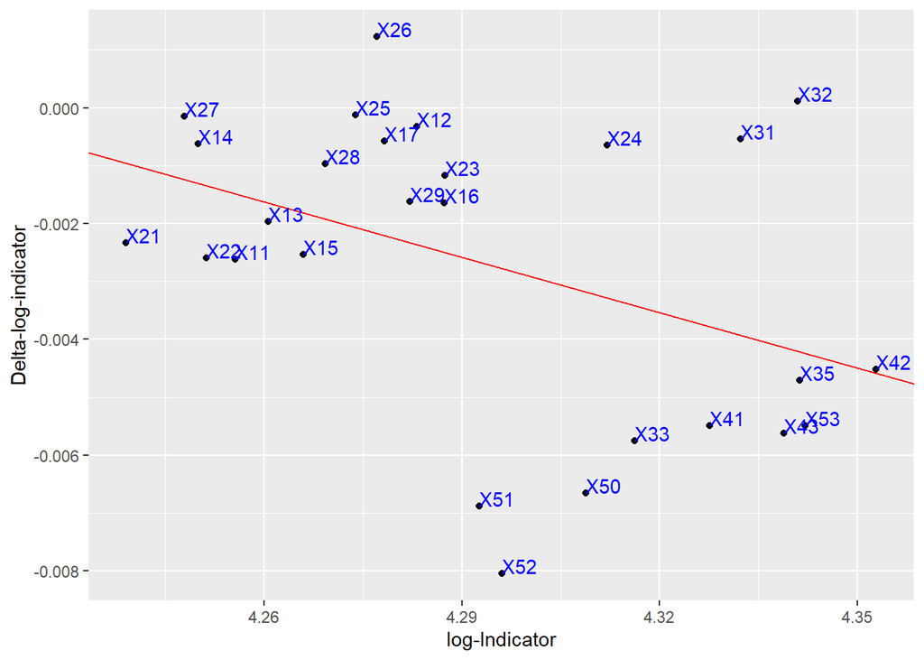

```r
qplot(empBC$res$workTB$indic,
empBC$res$workTB$deltaIndic,
xlab="log-Indicator",
ylab="Delta-log-indicator") +
geom_abline(intercept = as.numeric(empBC$res$summary[1,2]),
slope = as.numeric(empBC$res$summary[2,2]),
colour = "red") +
geom_text(aes(label=empBC$res$workTB$countries),
hjust=0, vjust=0,colour="blue")
```

Conforme observado, o valor do índice de beta convergência é negativo, então a convergência existe. Tal índice estuda se as economias com desempenho econômico inicial inferior tendem a crescer mais rápidas que os países que já apresentam bom desempenho; havendo convergência, tal afirmação é verídica.

### Sigma-convergence

```r
mySTB <- sigma_conv(life_exp_states, timeName="time")
mySTB
```

```
## $res
## # A tibble: 10 × 5
##     time stdDev     CV  mean devianceT
##    <dbl>  <dbl>  <dbl> <dbl>     <dbl>
##  1  2012   2.45 0.0335  73.2      162.
##  2  2013   2.47 0.0335  73.5      164.
##  3  2014   2.48 0.0336  73.8      166.
##  4  2015   2.49 0.0336  74.1      168.
##  5  2016   2.51 0.0337  74.4      170.
##  6  2017   2.52 0.0337  74.6      171.
##  7  2018   2.53 0.0338  74.9      173.
##  8  2019   2.54 0.0338  75.1      174.
##  9  2020   2.09 0.0283  73.7      117.
## 10  2021   2.26 0.0316  71.5      138.
##
## $msg
## NULL
##
## $err
## NULL
```

##### Departure Mean

```r
res <- departure_mean(oriTB = life_exp_states, sigmaTB = mySTB$res)
names(res$res)
```

```
## [1] "departures"      "squaredContrib"  "devianceContrib"
```

```r
res$res$departures
```

```
## # A tibble: 10 × 32
##     time stdDev     CV  mean devianceT   X11   X12   X13   X14   X15   X16   X17
##    <dbl>  <dbl>  <dbl> <dbl>     <dbl> <dbl> <dbl> <dbl> <dbl> <dbl> <dbl> <dbl>
##  1  2012   2.45 0.0335  73.2      162.    -1     0     0    -1     0     0     0
##  2  2013   2.47 0.0335  73.5      164.    -1     0     0    -1     0     0     0
##  3  2014   2.48 0.0336  73.8      166.    -1     0     0    -1     0     0     0
##  4  2015   2.49 0.0336  74.1      168.    -1     0    -1    -1     0     0     0
##  5  2016   2.51 0.0337  74.4      170.    -1     0    -1    -1     0     0     0
##  6  2017   2.52 0.0337  74.6      171.    -1     0    -1    -1     0     0     0
##  7  2018   2.53 0.0338  74.9      173.    -1     0    -1    -1     0     0     0
##  8  2019   2.54 0.0338  75.1      174.    -1     0    -1    -1    -1     0     0
##  9  2020   2.09 0.0283  73.7      117.    -1     0     0     0     0     0     0
## 10  2021   2.26 0.0316  71.5      138.    -1     0     0     0     0     0     0
## # ℹ 20 more variables: X21 <dbl>, X22 <dbl>, X23 <dbl>, X24 <dbl>, X25 <dbl>,
## #   X26 <dbl>, X27 <dbl>, X28 <dbl>, X29 <dbl>, X31 <dbl>, X32 <dbl>,
## #   X33 <dbl>, X35 <dbl>, X41 <dbl>, X42 <dbl>, X43 <dbl>, X50 <dbl>,
## #   X51 <dbl>, X52 <dbl>, X53 <dbl>
```

```r
res$res$squaredContrib
```

```
##          X11       X12      X13      X14      X15        X16        X17
## 1   7.420580 0.5686277 5.636228 9.759839 3.976331 0.20618326 1.24116104
## 2   7.937784 0.4725289 5.843859 9.532084 4.357270 0.20922154 1.22635117
## 3   8.472412 0.3730043 6.055245 9.307019 4.755630 0.20316722 1.23374499
## 4   8.975572 0.2980351 6.229646 9.035591 5.134420 0.20786845 1.20105364
## 5   9.484119 0.2397372 6.399026 8.818700 5.520759 0.21125940 1.18729273
## 6   9.889860 0.1978602 6.578275 8.613138 5.879727 0.21605281 1.17682318
## 7  10.320751 0.1541289 6.721536 8.367092 6.213018 0.23289561 1.19375857
## 8  10.690478 0.1366261 6.862459 8.177482 6.551704 0.23973717 1.20918532
## 9   6.216711 0.6032111 2.901344 2.867378 2.800044 0.04694444 0.10671111
## 10  6.850822 0.6124512 3.487210 3.123729 3.449962 0.04954746 0.06895487
##         X21       X22       X23      X24        X25        X26       X27
## 1  15.08603  9.205605 0.1972018 1.865754 2.02798697 1.42581289 10.654180
## 2  15.03429  9.906173 0.2474141 1.775803 1.89725117 1.05556598  9.969222
## 3  14.90532 10.567315 0.3144302 1.714160 1.79758573 0.77570425  9.307019
```

[output cut: 29 more lines]

```r
res$res$devianceContrib
```

```
##         X11        X12      X13      X14      X15        X16        X17
## 1  4.573060 0.35042666 3.473423 6.014669 2.450483 0.12706400 0.76488696
## 2  4.838103 0.28800778 3.561849 5.809833 2.655769 0.12752114 0.74746464
## 3  5.100471 0.22455204 3.645314 5.602912 2.862934 0.12230856 0.74272598
## 4  5.346031 0.17751571 3.710503 5.381779 3.058164 0.12381063 0.71537169
## 5  5.585790 0.14119621 3.768786 5.193884 3.251520 0.12442386 0.69927090
## 6  5.771398 0.11546473 3.838865 5.026345 3.431216 0.12608133 0.68675540
## 7  5.969744 0.08915149 3.887881 4.839706 3.593743 0.13471182 0.69049558
## 8  6.138594 0.07845224 3.940502 4.695603 3.762063 0.13765981 0.69432797
## 9  5.293566 0.51363781 2.470512 2.441589 2.384254 0.03997347 0.09086514
## 10 4.976664 0.44490482 2.533225 2.269180 2.506167 0.03599292 0.05009110
##         X21      X22       X23       X24        X25        X26      X27
## 1  9.297028 5.673114 0.1215290 1.1498029 1.24978204 0.87868185 6.565822
## 2  9.163443 6.037842 0.1507996 1.0823572 1.15638016 0.64337056 6.076270
## 3  8.973141 6.361622 0.1892899 1.0319402 1.08216336 0.46698119 5.602912
```

[output cut: 29 more lines]

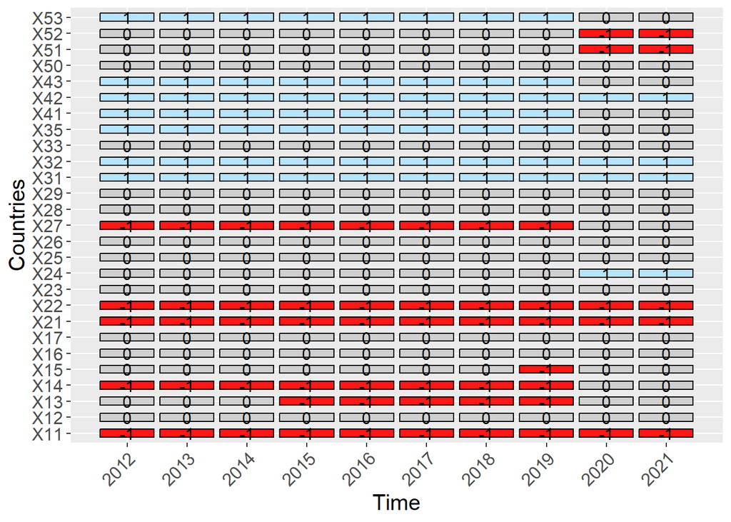

```r
myGG <- graph_departure(res$res$departures,
timeName = "time",
displace = 0.25,
displaceh = 0.45,
dimeFontNum = 4,
myfont_scale = 1.35,
x_angle = 45,
color_rect = c("-1"='red1', "0"='gray80',"1"='lightskyblue1'),
axis_name_y = "Countries",
axis_name_x = "Time",
alpha_color = 0.9
)

myGG
```

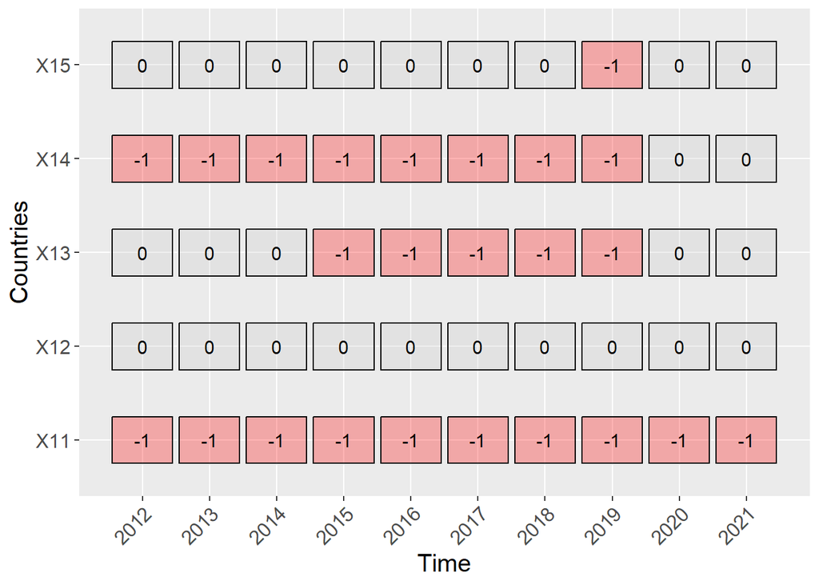

```r
myGG <- graph_departure(res$res$departures[,1:10],
timeName = "time",
displace = 0.25,
displaceh = 0.45,
dimeFontNum = 4,
myfont_scale = 1.35,
x_angle = 45,
color_rect = c("-1"='red1', "0"='gray80',"1"='lightskyblue1'),
axis_name_y = "Countries",
axis_name_x = "Time",
alpha_color = 0.29
)

myGG
```

A sigma convergência analisa a dispersão geral dos níveis de renda entre os países (ou estados). Ela ocorre quando essa disparidade diminui ao longo do tempo. Se o desvio padrão dos níveis de renda entre os países está diminuindo, isso significa convergência sigma.

### Gamma_convergence

```r
gamma_conv(life_exp_states,last=2021,ref=2012,timeName="time")
```

```
## $res
## [1] 0.7582165
##
## $msg
## NULL
##
## $err
## NULL
```

Este índice analisa as mudanças de um país no ranking. Quanto mais próximo ao 1, menos mudanças ocorreram. Quanto mais próximo ao 0, mais mudanças ocorreram.

### Delta_convergence

```r
delta_conv(life_exp_states,"time")
```

```
## $res
## # A tibble: 10 × 2
##     time delta
##    <int> <dbl>
##  1  2012  121.
##  2  2013  123.
##  3  2014  124.
##  4  2015  126.
##  5  2016  127.
##  6  2017  128.
##  7  2018  130.
##  8  2019  130.
##  9  2020  135.
## 10  2021  145.
##
## $msg
## NULL
##
## $err
## NULL
```

Este índice analisa o quão perto cada país está do país com o melhor desempenho absoluto. Se no decorrer do tempo o delta diminuir, há evidência de convergência. Caso contrário, se os números aumentarem, há divergência.

### Scoreboard

```r
resTB <- scoreb_yrs(life_exp_states,timeName = "time")
resTB
```

```
## $res
## $res$sigma_conv
## # A tibble: 10 × 9
##     time stdDev     CV  mean devianceT elle1in elle1su elle2in elle2su
##    <dbl>  <dbl>  <dbl> <dbl>     <dbl>   <dbl>   <dbl>   <dbl>   <dbl>
##  1  2012   2.45 0.0335  73.2      162.    72.0    74.4    70.8    75.7
##  2  2013   2.47 0.0335  73.5      164.    72.3    74.8    71.1    76.0
##  3  2014   2.48 0.0336  73.8      166.    72.6    75.1    71.3    76.3
##  4  2015   2.49 0.0336  74.1      168.    72.9    75.4    71.6    76.6
##  5  2016   2.51 0.0337  74.4      170.    73.1    75.6    71.9    76.9
##  6  2017   2.52 0.0337  74.6      171.    73.4    75.9    72.1    77.2
##  7  2018   2.53 0.0338  74.9      173.    73.6    76.2    72.4    77.4
##  8  2019   2.54 0.0338  75.1      174.    73.9    76.4    72.6    77.7
##  9  2020   2.09 0.0283  73.7      117.    72.7    74.7    71.6    75.8
## 10  2021   2.26 0.0316  71.5      138.    70.3    72.6    69.2    73.7
```

[output cut: 79 more lines]

O scoreboard nos exibe os valores brutos de um indicador.

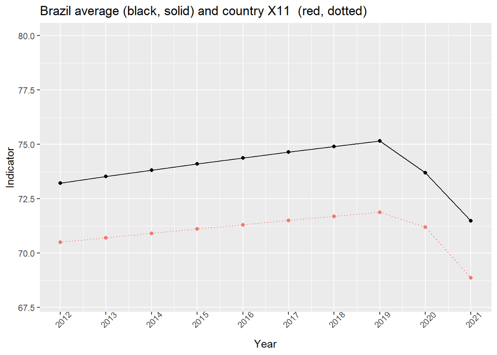

```r
selectedCountry <- "X11"
timeName <- "time"
myx_angle <- 45
outSig <- sigma_conv(life_exp_states, timeName = timeName,
time_0=2012,time_t=2021)
miniY <- min(life_exp_states[,- which(names(life_exp_states) == timeName )])
maxiY <- max(life_exp_states[,- which(names(life_exp_states) == timeName )])
estrattore<- life_exp_states[,timeName] >= 2012 & life_exp_states[,timeName] <= 2021
ttmp <- cbind(outSig$res, dplyr::select(life_exp_states[estrattore,], -contains(timeName)))

myG2 <-
ggplot(ttmp) + ggtitle(
paste("Brazil average (black, solid) and country",selectedCountry ," (red, dotted)") )+
geom_line(aes(x=ttmp[,timeName], y =ttmp[,"mean"]),colour="black") +
geom_point(aes(x=ttmp[,timeName],y =ttmp[,"mean"]),colour="black") +
# geom_line()+geom_point()+
ylim(c(miniY,maxiY)) + xlab("Year") +ylab("Indicator") +
theme(legend.position = "none")+
# add countries
geom_line( aes(x=ttmp[,timeName], y = ttmp[,"X11"],colour="red"),linetype="dotted") +
geom_point( aes(x=ttmp[,timeName], y = ttmp[,"X11"],colour="red")) +
ggplot2::scale_x_continuous(breaks = ttmp[,timeName],
labels = ttmp[,timeName]) +
ggplot2::theme(
axis.text.x=ggplot2::element_text(
#size = ggplot2::rel(myfont_scale ),
angle = myx_angle
#vjust = 1,
#hjust=1
))
myG2
```

Este gráfico representa uma comparação da média do país com a média do estado (sigma-convergence).

Também é possível representar graficamente os desvios em relação à partição definida anteriormente:

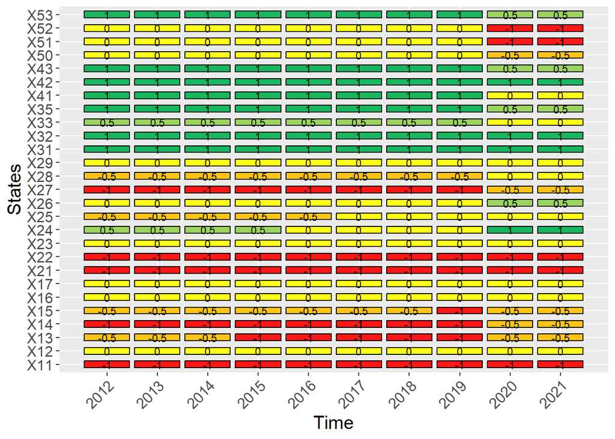

```r
obe_lvl <- scoreb_yrs(life_exp_states,timeName = timeName)$res$sco_level_num
# select subset of time
estrattore <- obe_lvl[,timeName] >= 2012 & obe_lvl[,timeName] <= 2021
scobelvl <- obe_lvl[estrattore,]
my_MSstd <- ms_dynam(scobelvl,
timeName = "time",
displace = 0.25,
displaceh = 0.45,
dimeFontNum = 3,
myfont_scale = 1.35,
x_angle = 45,
axis_name_y = "States",
axis_name_x = "Time",
alpha_color = 0.9
)
my_MSstd
```